# Data-Driven Segmentation of U.S. Colleges and Universities

Using K-Means Clustering on IPEDS Data

Benjamin Minor (Advisor: Dr. Cohen)

2025-12-09

## Introduction: Motivation

**Motivation:**  
Traditional labels (public/private, Carnegie type) often fail to capture how institutions actually operate when you examine resources and outcomes (Huberty, Jordan, and Brandt 2005; National Center for Education Statistics 2023).

- Institutions with different missions can look very similar numerically.
- Designations like *elite* or *regional* do not always reflect actual performance.
- Quantitative grouping provides a more objective baseline for comparison.

## Introduction: Research Question

- **Research question:**  
  **How do U.S. colleges naturally cluster when we focus strictly on quantitative metrics of financial resources and student outcomes per student?**
- **Why this matters:**
  - produces data-driven peer groups grounded in operating behavior
  - clarifies differences in resource intensity and student success
  - supports more accurate comparisons for funding, policy, and accountability (Texas Association for Institutional Research 2022)

## Introduction: Analytical Approach

- integrate 2023–24 IPEDS components into a unified dataset
- engineer per-FTE financial and outcome metrics
- apply standardization and Winsorization to prepare features (Kelchen 2019)
- assess candidate values of (k) using Elbow and Silhouette methods
- fit K-Means to identify institutional groupings

## Methods: Data Sources

**Data inputs:** Institution-level dataset built from 2023–24 IPEDS components (National Center for Education Statistics 2023).

- Finance
- Completions
- Admissions & Enrollment
- Fall Enrollment / FTE

## Methods: Feature Engineering

- revenue per FTE
- instructional spending per FTE
- student services spending per FTE
- completion rates
- tuition and net price
- selectivity indicators (admit rate, yield)

## Methods: Preprocessing

- standardize all numeric variables (mean 0, sd 1)
- Winsorize at 1% and 99% to limit extreme outliers
- remove institutions with structurally missing or invalid data

## Methods: Modeling

- K-Means clustering on standardized continuous features
- Euclidean distance as the similarity metric
- Elbow and Silhouette both support (k = 4)
- refit final model with multiple random starts for stability
- K-Means has a long history as a baseline clustering method (Lloyd 1982; Forgy 1965; Jain 2010)

## Data Exploration: Key Variation

**Initial patterns in the data reveal substantial institutional variation.**

- **Variation across institutions in:**
  - enrollment size
  - revenue and spending per FTE
  - completion rates and selectivity

## Modeling Results: Cluster Sizes

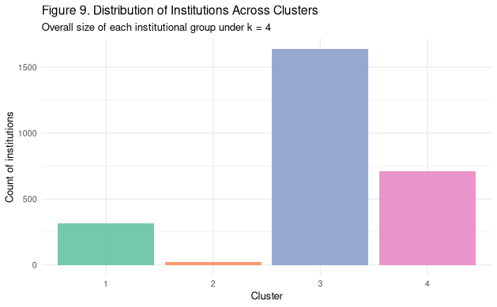

## Data Visualization: Variable Distributions by Cluster

[figure not shown]

## Modeling and Results: Interpretation

- Clusters cut across sector and Carnegie classifications.
- Institutions with similar operating models cluster together regardless of public/private status.
- Data-driven clustering surfaces patterns that are not obvious from traditional labels alone (Huberty, Jordan, and Brandt 2005; Elam 2016).

## Conclusion

- **k = 4** produces a stable, interpretable segmentation of U.S. institutions.
- Resource intensity plus completion outcomes shape cluster membership the most.
- These clusters provide clearer institutional peer groups than legacy labels and can support more targeted benchmarking and policy analysis (Texas Association for Institutional Research 2022; Mohd Talib, Abd Majid, and Sahran 2023).

## Conclusion: Limitations & Future Work

- **Limitations:**
  - K-Means assumes roughly spherical clusters in standardized space
  - feature selection strongly influences cluster structure
  - results are descriptive, not causal
- **Future Work:**
  - experiment with Gaussian Mixture Models or hierarchical clustering
  - incorporate multi-year financial and outcome trends
  - compare clusters by student demographics and debt outcomes

## References

Elam, Jordan. 2016. “Proposal of a New Method to Classify Higher Education Institutions.” https://digitalcommons.otterbein.edu/cgi/viewcontent.cgi?article=1031&context=stu_dist.

Forgy, Edward W. 1965. “Cluster Analysis of Multivariate Data: Efficiency Versus Interpretability of Classifications.” *Biometrics* 21 (3): 768–69.

Huberty, Carl J., Ellen M. Jordan, and W. Charles Brandt. 2005. “Cluster Analysis in Higher Education Research.” In *Higher Education: Handbook of Theory and Research*, 20:437–57. Dordrecht: Springer. https://link.springer.com/content/pdf/10.1007/1-4020-3279-X_8.pdf.

Jain, Anil K. 2010. *Data Clustering: 50 Years Beyond k-Means*. *Pattern Recognition Letters*. Vol. 31. 8. Elsevier. https://doi.org/10.1016/j.patrec.2009.09.011.

Kelchen, Robert. 2019. “Merging Data to Facilitate Analyses.” Seton Hall University. https://robertkelchen.com/wp-content/uploads/2019/11/kelchen_merging_original.pdf.

Lloyd, Stuart P. 1982. “Least Squares Quantization in PCM.” *IEEE Transactions on Information Theory* 28 (2): 129–37. https://doi.org/10.1109/TIT.1982.1056489.

Mohd Talib, Nurul Izzati, Noor Azilah Abd Majid, and Shamala Sahran. 2023. “Identification of Student Behavioral Patterns in Higher Education Using k-Means Clustering and Support Vector Machine.” *Applied Sciences* 13 (5): 3267. https://doi.org/10.3390/app13053267.

National Center for Education Statistics. 2023. “Institutional Groupings in IPEDS: Considerations for Data Use.” https://nces.ed.gov/ipeds/use-the-data/institutional-groupings-in-ipeds.

Texas Association for Institutional Research. 2022. “A Hybrid Approach to Identifying National Peer Institutions.” https://www.texas-air.org/wp-content/uploads/2022/03/E3-A-Hybrid-Approach-to-Identifying-National-Peer-Institutions.pdf.